# Fee_data

Adrian D. Garcia

June 2020

# Intro

## Getting Started

```r
library(waffle) #Waffle graphs
library(tidyverse) #For Data Analysis
library(lubridate) #For working with dates
library(DT) #For visualizing tables
```

We repulled the data to replace the “Annual Report Adjusted Expense Ratio” the “Annual Report Net Expense Ratio” figure previously used. [Here’s why](https://www.morningstar.com/articles/969612/one-expense-ratio-to-rule-them-all).

For the 2019 fee study from Morningstar the analyst says they used the lesser of Annual Report Net Expense Ratio and Annual Report Adjusted for each fund. “… adjusted excludes short interest, reverse repo rates, among other things that make it hard to compare fixed income and alt funds across firms. However, we didn’t JUST use adjusted because it’s not exhaustive of the whole universe we found – a handful of funds had missing adjusted expense ratios, but every one had a net expense ratio.”

```r
# Full <- read_csv("MS_Fee_Report_071020_Full.csv",
#                  guess_max = 25000)

Full <- read_csv("MS_Fee_Report_072920_Fulla.csv",
                 guess_max = 25000)
```

I made the following adjustments to the data:

- Replaced spaces in the column names with periods.
- Removed fund of funds
- Renamed “Annual Report Adjusted Expense Ratio” to “Annual Report Net Expense Ratio” (this is just to not rewrite code)
- Combined the following firms Eaton Vance & Calvert Research and Management, SPDR State Street Global Advisors & "State Street Global Advisors, Nuveen and TIAA Investments
- Calculated the average assets for 2017, 2018 and 2019.
- Multiplied the annual average asset figures by the expense ratio (to use later for asset-weighted calculations).
- Calculated the percent change in net expense ratios from 2017 to 2018 and 2018 to 2019.

*21,111 rows, 97 columns **Adjusted_Data***

```r
Adjusted_Data <- Full %>%
  rename_all(make.names) %>%
  filter(Fund.of..Funds != "Yes") %>%
  rename(
    Annual.Report..Net.Expense..Ratio..Year2017 = Annual.Report.Adjusted.Expense.Ratio..Year2017,
    Annual.Report..Net.Expense..Ratio..Year2018 = Annual.Report.Adjusted.Expense.Ratio..Year2018,
    Annual.Report..Net.Expense..Ratio..Year2019 = Annual.Report.Adjusted.Expense.Ratio..Year2019
    ) %>%
  mutate(
    Firm.Name = case_when(
      Firm.Name == "SPDR State Street Global Advisors" ~ "State Street Global Advisors",
      Firm.Name == "Calvert Research and Management" ~ "Eaton Vance",
      Firm.Name == "Nuveen" ~ "TIAA Investments",
      TRUE ~ as.character(Firm.Name)
    )
  ) %>%
  mutate(
    Net_Asst_2017_AVG = rowMeans(.[, 54:65], na.rm = TRUE),
    Net_Asst_2018_AVG = rowMeans(.[, 66:77], na.rm = TRUE),
    Net_Asst_2019_AVG = rowMeans(.[, 78:89], na.rm = TRUE),
    Asst_By_Fee_2017 = Net_Asst_2017_AVG * Annual.Report..Net.Expense..Ratio..Year2017,
    Asst_By_Fee_2018 = Net_Asst_2018_AVG * Annual.Report..Net.Expense..Ratio..Year2018,
    Asst_By_Fee_2019 = Net_Asst_2019_AVG * Annual.Report..Net.Expense..Ratio..Year2019,
    Pct_Change_2017_2018 = (
      Annual.Report..Net.Expense..Ratio..Year2018 - Annual.Report..Net.Expense..Ratio..Year2017
    ) / Annual.Report..Net.Expense..Ratio..Year2017 * 100,
    Pct_Change_2018_2019 = (
      Annual.Report..Net.Expense..Ratio..Year2019 - Annual.Report..Net.Expense..Ratio..Year2018
    ) / Annual.Report..Net.Expense..Ratio..Year2018 * 100
  )

write_csv(Adjusted_Data,
          "~/Data/Fee_Data/Fee_Data/results/MS_Fee_Report_071020_ag.csv")
```

# ACTIVE PRODUCTS

## Fund families with the lowest/highes fees across active products

Here I am looking at the fund families with the lowest and highest overall fees across active products. I start by filtering out index funds and removing fees that are NA (blank) for 2019. 19,199 rows remain.

Additions:

- Group the data by firm
- Count how many shareclasses each firm has
- Sum their net assets 2019

Filter:

- Firms with at least 50 share classes
- Firms with at least $25 billion in assets in 2019

Next steps:

- Group the data by firm
- Count how many shareclasses each firm has
- Sum their adjusted assets (individually) for 2017, 2018 and 2019
- Sum their net assets (individually) for 2017, 2018 and 2019
- Divide the total adjusted assets by the total net asssets to calculate asset-weighted fees for each fund shop (individually) for 2017, 2018 and 2019

*53 rows **Active_Fees***

```r
ActiveFunds <- Adjusted_Data %>%
  filter(
    Net_Asst_2019_AVG != 0 &
      Index..Fund != "Yes" &
      !is.na(Annual.Report..Net.Expense..Ratio..Year2019)
  ) %>%
  group_by(Firm.Name) %>%
  mutate(
    Count = n(),
    Sum_Assets_2019 = sum(Net_Asst_2019_AVG, na.rm = TRUE)
  ) %>%
  ungroup() %>%
  filter(Count >= 50 &
           Sum_Assets_2019 >= 2.5e+10
         )

Active_Fees <- ActiveFunds %>%
  group_by(Firm.Name) %>%
  summarise(
    Count = n(),
    Sum_Assts_Wted_2017 = sum(Asst_By_Fee_2017, na.rm = TRUE),
    Sum_Assets_2017 = sum(Net_Asst_2017_AVG, na.rm = TRUE),
    Fee_Wted_2017 = Sum_Assts_Wted_2017 / Sum_Assets_2017,
    Sum_Assts_Wted_2018 = sum(Asst_By_Fee_2018, na.rm = TRUE),
    Sum_Assets_2018 = sum(Net_Asst_2018_AVG, na.rm = TRUE),
    Fee_Wted_2018 = Sum_Assts_Wted_2018 / Sum_Assets_2018,
    Sum_Assts_Wted_2019 = sum(Asst_By_Fee_2019, na.rm = TRUE),
    Sum_Assets_2019 = sum(Net_Asst_2019_AVG, na.rm = TRUE),
   Fee_Wted_2019 = Sum_Assts_Wted_2019 / Sum_Assets_2019
  )

write_csv(Active_Fees,
          "~/Data/Fee_Data/Fee_Data/results/ACTIVE/fees_activefunds_firm.csv")

Active_HighFees <- Active_Fees %>%
  arrange(desc(Fee_Wted_2019)) %>%
  top_n(10, Fee_Wted_2019)

Active_LowFees <- Active_Fees %>%
  arrange(Fee_Wted_2019) %>%
  top_n(-10, Fee_Wted_2019)
```

Here’s a look at some of the above data. Full results saved as **fees_activefunds_firm.csv** in **Results** folder.

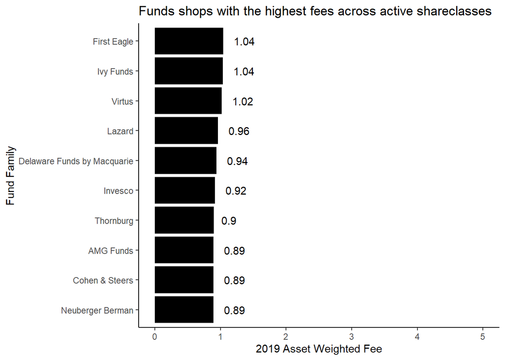

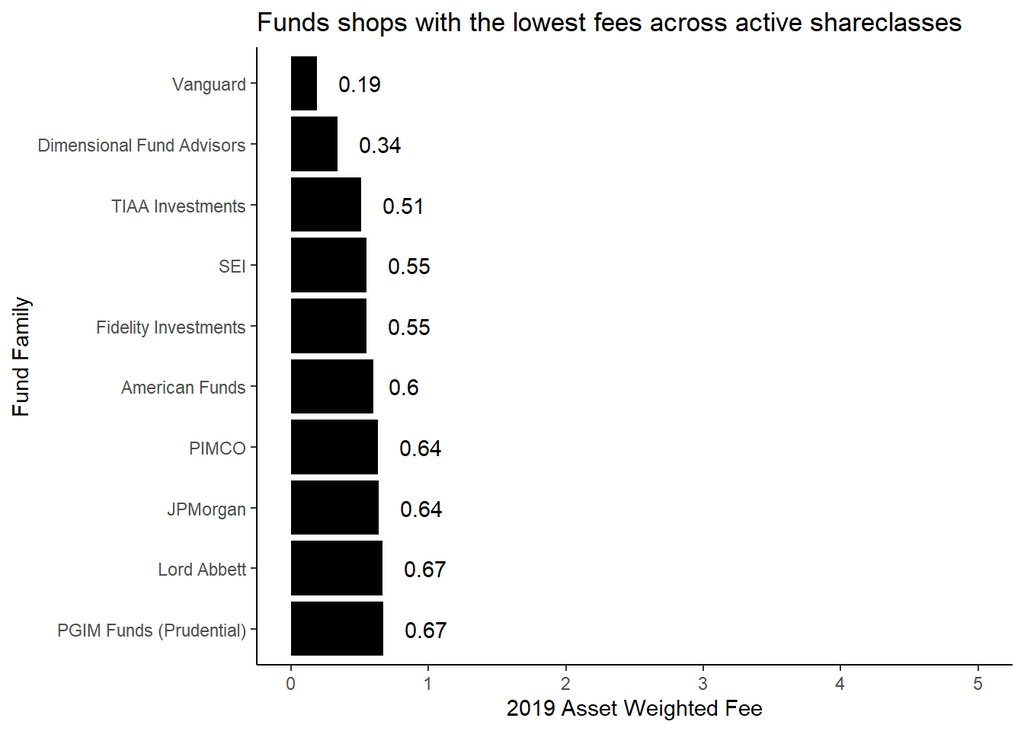

## Summary

Here I the average net expense ratio, on an asset weighted basis, for 2017, 2018 and 2019.

I take **ActiveFunds**

Next steps:

- Ungroup the data by firm
- Count how many shareclasses there are total
- Sum the adjusted assets (individually) for 2017, 2018 and 2019
- Sum their net assets (individually) for 2017, 2018 and 2019
- Divide the total adjusted assets by the total net asssets to calculate asset-weighted fees for each fund shop (individually) for 2017, 2018 and 2019

I drop the adjusted asset figures above and gather all the columns.

```r
Active_Summary <- ActiveFunds %>%
  ungroup() %>%
  summarise(
    Count = n(),
    Sum_Assts_Wted_2017 = sum(Asst_By_Fee_2017, na.rm = TRUE),
    Sum_Assets_2017 = sum(Net_Asst_2017_AVG, na.rm = TRUE),
    Fee_Wted_2017 = Sum_Assts_Wted_2017 / Sum_Assets_2017,
    Sum_Assts_Wted_2018 = sum(Asst_By_Fee_2018, na.rm = TRUE),
    Sum_Assets_2018 = sum(Net_Asst_2018_AVG, na.rm = TRUE),
    Fee_Wted_2018 = Sum_Assts_Wted_2018 / Sum_Assets_2018,
    Sum_Assts_Wted_2019 = sum(Asst_By_Fee_2019, na.rm = TRUE),
    Sum_Assets_2019 = sum(Net_Asst_2019_AVG, na.rm = TRUE),
   Fee_Wted_2019 = Sum_Assts_Wted_2019 / Sum_Assets_2019
  ) %>%
  select(
    1,
    3:4,
    6:7,
    9:10
  ) %>%
  gather(
    key = "Field",
    value, "Count",
    2:7
  )

write_csv(Active_Summary,
          "~/Data/Fee_Data/Fee_Data/results/ACTIVE/fees_activefunds_summary.csv")

datatable(Active_Summary)
```

|  | Field | value |
| --- | --- | --- |
| 1 | Count | 13792 |
| 2 | Sum_Assets_2017 | 8677468552355.01 |
| 3 | Fee_Wted_2017 | 0.683135628470195 |
| 4 | Sum_Assets_2018 | 9366513508151.47 |
| 5 | Fee_Wted_2018 | 0.647282400254051 |
| 6 | Sum_Assets_2019 | 9574660776678.97 |
| 7 | Fee_Wted_2019 | 0.625716298544227 |

## Fees by Type of Active Fund Category

Here I am looking at fund families’ fees for each U.S. category types for active funds. I start by pulling in the filtered data from **ActiveFunds**.

Next steps:

- Group the data by firm and U.S. category group
- Sum their adjusted assets (individually) for 2017, 2018 and 2019
- Sum their net assets (individually) for 2017, 2018 and 2019
- Divide the total adjusted assets by the total net asssets to calculate asset-weighted fees for each fund shop and category group (individually) for 2018 and 2019
- Count how many shareclasses there are for each category

Next:

- Group by firm name
- Sum total share classes for each fund family
- Sum total adjusted assets
- Sum total net assets
- Calculate average fee for each fund family
- Calculate percent of assets each fund family has in each category group

```r
Active_Cat <- ActiveFunds %>%
  group_by(Firm.Name, US.Category.Group) %>%
  summarise(
    Asst_Wted_Cat_2017 = sum(Asst_By_Fee_2017, na.rm = TRUE),
    Sum_Assets_Cat_2017 = sum(Net_Asst_2017_AVG, na.rm = TRUE),
    Fee_Wted_Cat_2017 = Asst_Wted_Cat_2017 / Sum_Assets_Cat_2017,
    Asst_Wted_Cat_2018 = sum(Asst_By_Fee_2018, na.rm = TRUE),
    Sum_Assets_Cat_2018 = sum(Net_Asst_2018_AVG, na.rm = TRUE),
    Fee_Wted_Cat_2018 = Asst_Wted_Cat_2018 / Sum_Assets_Cat_2018,
    Asst_Wted_Cat_2019 = sum(Asst_By_Fee_2019, na.rm = TRUE),
    Sum_Assets_Cat_2019 = sum(Net_Asst_2019_AVG, na.rm = TRUE),
    Fee_Wted_Cat_2019 = Asst_Wted_Cat_2019 / Sum_Assets_Cat_2019,
    Cat_Count = n()
  ) %>%
  group_by(Firm.Name) %>%
  mutate(
    ShareClass_Count = sum(Cat_Count, na.rm = TRUE),
    Sum_Assts_Wted_2018 = sum(Asst_Wted_Cat_2018, na.rm = TRUE),
    Sum_Assets_2018 = sum(Sum_Assets_Cat_2018, na.rm = TRUE),
    Fee_Wted_2018 = Sum_Assts_Wted_2018 / Sum_Assets_2018,
    pct_assets_2018 = (Sum_Assets_Cat_2018 / Sum_Assets_2018) * 100,
    Sum_Assts_Wted_2019 = sum(Asst_Wted_Cat_2019, na.rm = TRUE),
    Sum_Assets_2019 = sum(Sum_Assets_Cat_2019, na.rm = TRUE),
    Fee_Wted_2019 = Sum_Assts_Wted_2019 / Sum_Assets_2019,
    pct_assets_2019 = (Sum_Assets_Cat_2019 / Sum_Assets_2019) * 100
    )

write_csv(Active_Cat,
          "~/Data/Fee_Data/Fee_Data/results/ACTIVE/cat_activefunds_firm.csv")

Active_Cat_Sum <- Active_Cat %>%
  group_by(US.Category.Group) %>%
  summarise(
    SHARECLASSES = sum(Cat_Count),
    FEE = (sum(Asst_Wted_Cat_2019)/sum(Sum_Assets_Cat_2019)),
    ASSETS = sum(Sum_Assets_Cat_2019)
    ) %>%
  mutate(
    pct = round(ASSETS / sum(ASSETS)*100,2)
    )

Lowcost_Active_Firms <- Active_LowFees$Firm.Name
Highcost_Active_Firms <- Active_HighFees$Firm.Name

Active_Cat_Pct <- Active_Cat %>%
  select(
    Firm.Name,
    US.Category.Group,
    Cat_Count,
    Sum_Assets_Cat_2019,
    Sum_Assets_2019,
    Fee_Wted_Cat_2019,
    Fee_Wted_2019,
    pct_assets_2019
  ) %>%
  mutate(Type =
           case_when(
             grepl("Equity", US.Category.Group) ~ "Equity",
             grepl("Bond", US.Category.Group) ~ "Bond",
             TRUE ~ "Other"
           )) %>%
  filter(Firm.Name %in% Lowcost_Active_Firms |
           Firm.Name %in% Highcost_Active_Firms) %>%
  group_by(Firm.Name) %>%
  arrange(-Fee_Wted_2019, .by_group = TRUE)

write_csv(Active_Cat_Pct,
          "~/Data/Fee_Data/Fee_Data/results/ACTIVE/cat_activefunds_highlow.csv")
```

Here’s a look at some of the above data. Full results saved as **cat_activefunds_firm.csv** in **Results** folder.

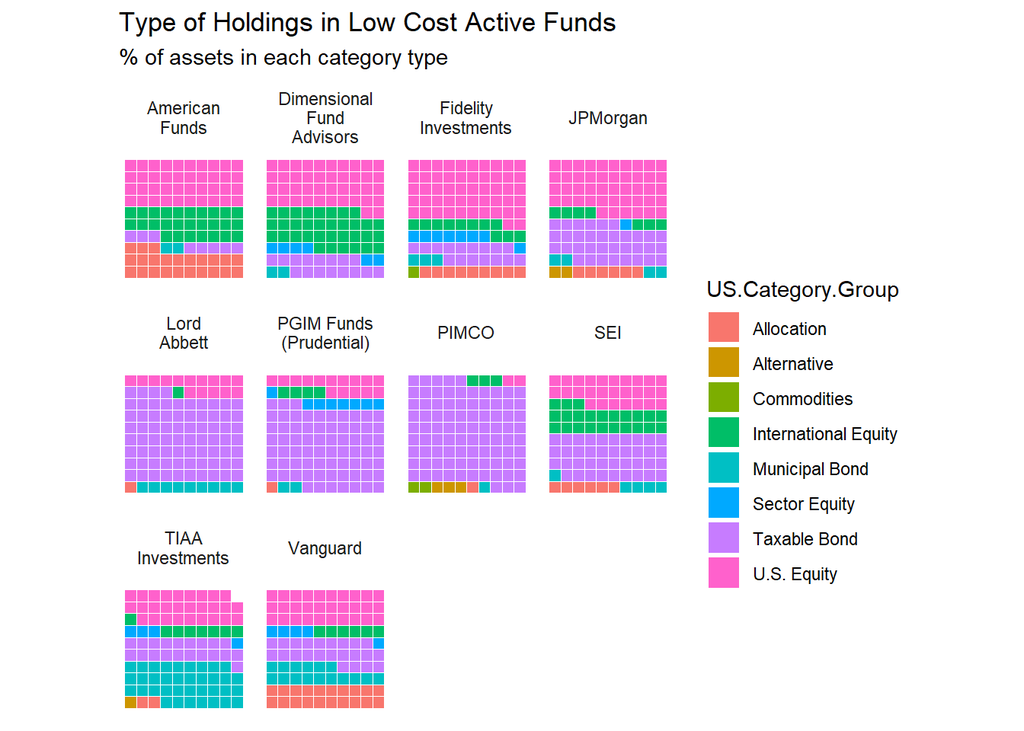

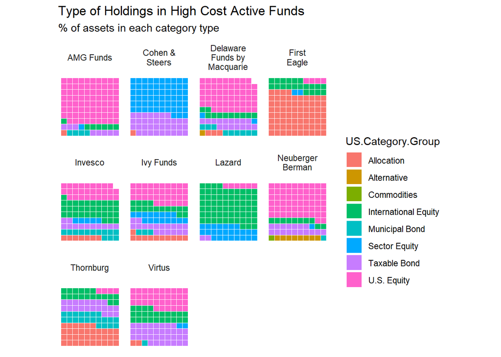

## Fees by Type of Morningstar Fund Category (ACTIVE)

Here I am looking at fund families’ fees for each Morningsar category types for active funds. I start by pulling in the filtered data from **ActiveFunds**.

Next steps:

- Group the data by firm and Morningstar category group
- Sum their adjusted assets (individually) for 2017, 2018 and 2019
- Sum their net assets (individually) for 2017, 2018 and 2019
- Divide the total adjusted assets by the total net asssets to calculate asset-weighted fees for each fund shop and category group (individually) for 2018 and 2019
- Count how many shareclasses there are for each category

Next:

- Group by firm name
- Sum total share classes for each fund family
- Sum total adjusted assets
- Sum total net assets
- Calculate average fee for each fund family
- Calculate percent of assets each fund family has in each category group

```r
Active_MSCat <- ActiveFunds %>%
  group_by(Firm.Name, Morningstar.Category) %>%
  summarise(
    Asst_Wted_Cat_2017 = sum(Asst_By_Fee_2017, na.rm = TRUE),
    Sum_Assets_Cat_2017 = sum(Net_Asst_2017_AVG, na.rm = TRUE),
    Fee_Wted_Cat_2017 = Asst_Wted_Cat_2017 / Sum_Assets_Cat_2017,
    Asst_Wted_Cat_2018 = sum(Asst_By_Fee_2018, na.rm = TRUE),
    Sum_Assets_Cat_2018 = sum(Net_Asst_2018_AVG, na.rm = TRUE),
    Fee_Wted_Cat_2018 = Asst_Wted_Cat_2018 / Sum_Assets_Cat_2018,
    Asst_Wted_Cat_2019 = sum(Asst_By_Fee_2019, na.rm = TRUE),
    Sum_Assets_Cat_2019 = sum(Net_Asst_2019_AVG, na.rm = TRUE),
    Fee_Wted_Cat_2019 = Asst_Wted_Cat_2019 / Sum_Assets_Cat_2019,
    Cat_Count = n()
  ) %>%
  group_by(Firm.Name) %>%
  mutate(
    ShareClass_Count = sum(Cat_Count, na.rm = TRUE),
    Sum_Assts_Wted_2018 = sum(Asst_Wted_Cat_2018, na.rm = TRUE),
    Sum_Assets_2018 = sum(Sum_Assets_Cat_2018, na.rm = TRUE),
    Fee_Wted_2018 = Sum_Assts_Wted_2018 / Sum_Assets_2018,
    pct_assets_2018 = (Sum_Assets_Cat_2018 / Sum_Assets_2018) * 100,
    Sum_Assts_Wted_2019 = sum(Asst_Wted_Cat_2019, na.rm = TRUE),
    Sum_Assets_2019 = sum(Sum_Assets_Cat_2019, na.rm = TRUE),
    Fee_Wted_2019 = Sum_Assts_Wted_2019 / Sum_Assets_2019,
    pct_assets_2019 = (Sum_Assets_Cat_2019 / Sum_Assets_2019) * 100
  )

write_csv(Active_MSCat,
          "~/Data/Fee_Data/Fee_Data/results/ACTIVE/MScat_activefunds.csv")


Active_MSCat_Sum <- Active_MSCat %>%
  group_by(Morningstar.Category) %>%
  summarise(
    SHARECLASSES = sum(Cat_Count),
    FEE = round((sum(Asst_Wted_Cat_2019)/sum(Sum_Assets_Cat_2019)),2),
    ASSETS = sum(Sum_Assets_Cat_2019)
  ) %>%
  mutate(
    pct = round(ASSETS / sum(ASSETS)*100,2),
    RANK = rank(-FEE)
  )

Lowcost_Active_Firms <- Active_LowFees$Firm.Name
Highcost_Active_Firms <- Active_HighFees$Firm.Name

Active_MSCat_Pct <- Active_MSCat %>%
  select(
    Firm.Name,
    Morningstar.Category,
    Cat_Count,
    Sum_Assets_Cat_2019,
    Sum_Assets_2019,
    Fee_Wted_Cat_2019,
    Fee_Wted_2019,
    pct_assets_2019
  ) %>%
  filter(Firm.Name %in% Lowcost_Active_Firms |
           Firm.Name %in% Highcost_Active_Firms) %>%
  group_by(Firm.Name) %>%
  arrange(-Fee_Wted_2019, .by_group = TRUE)

write_csv(Active_MSCat_Pct,
          "~/Data/Fee_Data/Fee_Data/results/ACTIVE/MScat_activefunds_highlow.csv")
```

Here’s a look at some of the above data. Full results saved as **MScat_activefunds.csv** in **Results** folder.

|  | Morningstar.Category | SHARECLASSES | FEE | ASSETS | pct | RANK |
| --- | --- | --- | --- | --- | --- | --- |
| 1 | US Fund Allocation--15% to 30% Equity | 46 | 0.76 | 19882163199.9167 | 0.21 | 40.5 |
| 2 | US Fund Allocation--30% to 50% Equity | 192 | 0.59 | 211644566236.967 | 2.21 | 69 |
| 3 | US Fund Allocation--50% to 70% Equity | 249 | 0.52 | 514251123074.647 | 5.37 | 78.5 |
| 4 | US Fund Allocation--70% to 85% Equity | 58 | 0.59 | 126743569124.167 | 1.32 | 69 |
| 5 | US Fund Allocation--85%+ Equity | 9 | 0.74 | 21531109055 | 0.22 | 43.5 |
| 6 | US Fund Bank Loan | 192 | 0.82 | 94206933051.45 | 0.98 | 31.5 |
| 7 | US Fund Bear Market | 8 | 0.76 | 1667040850.41667 | 0.02 | 40.5 |
| 8 | US Fund China Region | 41 | 1.21 | 1990798726.41667 | 0.02 | 6 |
| 9 | US Fund Commodities Broad Basket | 70 | 0.57 | 23217467705.6786 | 0.24 | 74 |
| 10 | US Fund Communications | 18 | 0.7 | 7272418434.25 | 0.08 | 51 |

[output cut: 95 more lines]

## Fee changes among active share classes

Next I create a category (FeeChange) that puts the percent changes (continous) in buckets (categorical). After that I just count the buckets.

Filter:

- Firms with at least 50 share classes
- Firms with at least $25 billion in assets

```r
Active_Shareclass <- Adjusted_Data %>%
  filter(
    Annual.Report..Net.Expense..Ratio..Year2018 != 0 &
      !is.na(Annual.Report..Net.Expense..Ratio..Year2018) &
      !is.na(Annual.Report..Net.Expense..Ratio..Year2019) &
      Index..Fund == "No"
  ) %>%
  mutate(
    FeeChange =
      cut(
        Pct_Change_2018_2019,
        breaks = c(-Inf,-0.001, 0, Inf),
        labels = c("Cut", "No Change", "Hike"),
        include.lowest = TRUE,
        right = TRUE
      )
    )

Active_Summary_Shareclass <- Active_Shareclass %>%
  group_by(Firm.Name,
           FeeChange) %>%
  summarise(count = n(),
    Sum_Assets = sum(Net_Asst_2019_AVG, na.rm = TRUE)
    ) %>%
  group_by(Firm.Name) %>%
  mutate(
    total_assets = sum(Sum_Assets),
    assets_pct = Sum_Assets / total_assets * 100,
    total_count = sum(count),
    count_pct = count / total_count * 100
  ) %>%
  filter(total_count >= 50 &
           total_assets >= 2.5e+10
         )

write_csv(
  Active_Summary_Shareclass,
  "~/Data/Fee_Data/Fee_Data/results/ACTIVE/shareclass_changes_activefunds.csv"
  )
```

Here’s a look at some of the above data. Full results saved as **shareclass_changes_activefunds.csv** in **Results** folder.

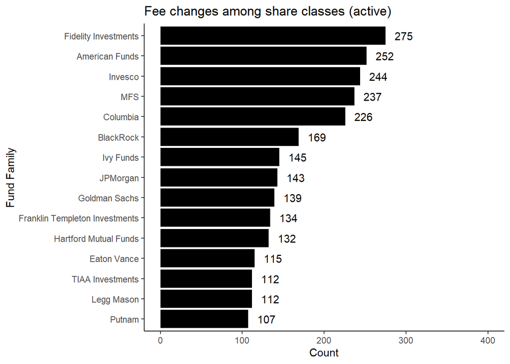

# PASSIVE

## Fund families with the lowest/highes fees across passive products

Here I am looking at the fund families with the lowest and highest overall fees across passive products. I start by filtering out non-index funds and removing fees that are NA (blank) for 2019. 1,053 rows remain.

Filter:

- Firms with at least 10 share classes
- Firms with at least $1 in assets

Next steps:

- Group the data by firm
- Sum their adjusted assets
- Sum their net assets
- Divide the total adjusted assets by the total net asssets to calculate asset-weighted fees for each fund shop.

*25 rows remain **ActiveFees***

I select the top and bottom 15 fund families based on the results.

```r
PassiveFunds <- Adjusted_Data %>%
  filter(
    Net_Asst_2019_AVG != 0 &
      Index..Fund != "No" &
      !is.na(Annual.Report..Net.Expense..Ratio..Year2019)
  ) %>%
  group_by(Firm.Name) %>%
  mutate(
    Count = n(),
    Sum_Assets_2019 = sum(Net_Asst_2019_AVG, na.rm = TRUE)
  ) %>%
  ungroup() %>%
  filter(Count >= 10,
         Sum_Assets_2019 > 0
         )

Passive_Fees <- PassiveFunds %>%
  group_by(Firm.Name) %>%
  summarise(
    Count = n(),
    Sum_Assts_Wted_2017 = sum(Asst_By_Fee_2017, na.rm = TRUE),
    Sum_Assets_2017 = sum(Net_Asst_2017_AVG, na.rm = TRUE),
    Fee_Wted_2017 = Sum_Assts_Wted_2017 / Sum_Assets_2017,
    Sum_Assts_Wted_2018 = sum(Asst_By_Fee_2018, na.rm = TRUE),
    Sum_Assets_2018 = sum(Net_Asst_2018_AVG, na.rm = TRUE),
    Fee_Wted_2018 = Sum_Assts_Wted_2018 / Sum_Assets_2018,
    Sum_Assts_Wted_2019 = sum(Asst_By_Fee_2019, na.rm = TRUE),
    Sum_Assets_2019 = sum(Net_Asst_2019_AVG, na.rm = TRUE),
    Fee_Wted_2019 = Sum_Assts_Wted_2019 / Sum_Assets_2019
  )

write_csv(Passive_Fees,
          "~/Data/Fee_Data/Fee_Data/results/PASSIVE/fees_passivefunds_firm.csv")


Passive_HighFees <- Passive_Fees %>%
  arrange(desc(Fee_Wted_2019)) %>%
  top_n(15, Fee_Wted_2019)

Passive_LowFees <- Passive_Fees %>%
  arrange(Fee_Wted_2019) %>%
  top_n(-15, Fee_Wted_2019)
```

Here’s a look at some of the above data. Full results saved as **fees_passivefunds_firm.csv** in **Results** folder.

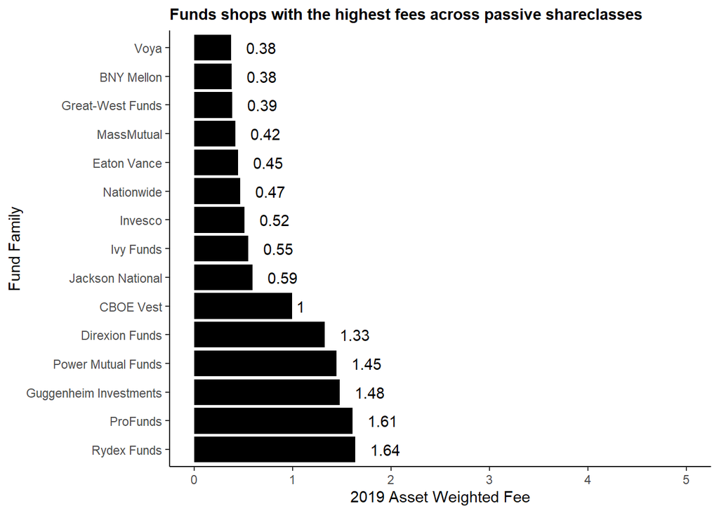

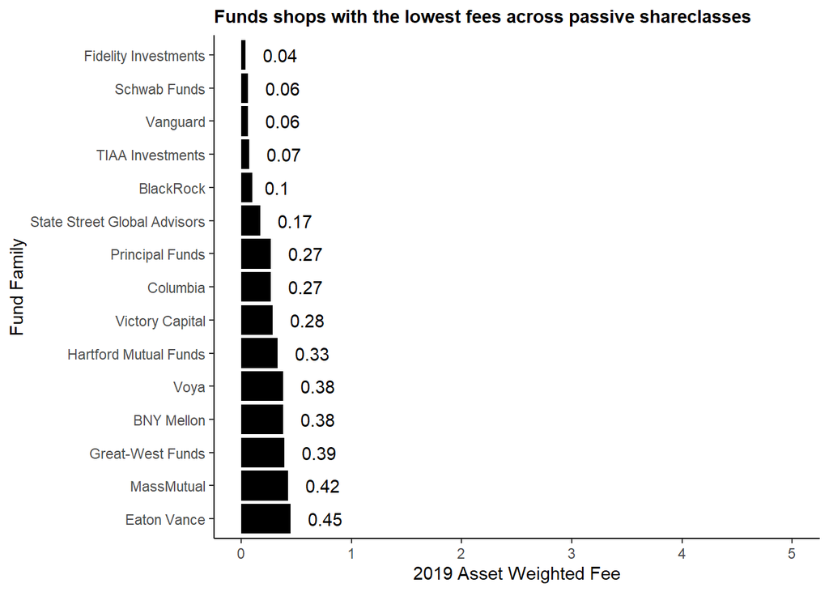

## Summary

Here I the average net expense ratio, on an asset weighted basis, for 2017, 2018 and 2019.

I take **PassiveFunds**

Next steps:

- Ungroup the data by firm
- Count how many shareclasses there are total
- Sum the adjusted assets (individually) for 2017, 2018 and 2019
- Sum their net assets (individually) for 2017, 2018 and 2019
- Divide the total adjusted assets by the total net asssets to calculate asset-weighted fees for each fund shop (individually) for 2017, 2018 and 2019

I drop the adjusted asset figures above and gather all the columns.

```r
Passive_Summary <- PassiveFunds %>%
  ungroup() %>%
  summarise(
    Count = n(),
    Sum_Assts_Wted_2017 = sum(Asst_By_Fee_2017, na.rm = TRUE),
    Sum_Assets_2017 = sum(Net_Asst_2017_AVG, na.rm = TRUE),
    Fee_Wted_2017 = Sum_Assts_Wted_2017 / Sum_Assets_2017,
    Sum_Assts_Wted_2018 = sum(Asst_By_Fee_2018, na.rm = TRUE),
    Sum_Assets_2018 = sum(Net_Asst_2018_AVG, na.rm = TRUE),
    Fee_Wted_2018 = Sum_Assts_Wted_2018 / Sum_Assets_2018,
    Sum_Assts_Wted_2019 = sum(Asst_By_Fee_2019, na.rm = TRUE),
    Sum_Assets_2019 = sum(Net_Asst_2019_AVG, na.rm = TRUE),
    Fee_Wted_2019 = Sum_Assts_Wted_2019 / Sum_Assets_2019
  ) %>%
  select(
    1,
    3:4,
    6:7,
    9:10
  ) %>%
  gather(
    key = "Field",
    value, "Count",
    2:7
  )

write_csv(Passive_Summary,
          "~/Data/Fee_Data/Fee_Data/results/PASSIVE/fees_activefunds_summary.csv")

datatable(Passive_Summary)
```

|  | Field | value |
| --- | --- | --- |
| 1 | Count | 924 |
| 2 | Sum_Assets_2017 | 2558155282889.73 |
| 3 | Fee_Wted_2017 | 0.0906743129251006 |
| 4 | Sum_Assets_2018 | 3029499335232.2 |
| 5 | Fee_Wted_2018 | 0.083796635554023 |
| 6 | Sum_Assets_2019 | 3611495736103.92 |
| 7 | Fee_Wted_2019 | 0.0751417641041227 |

## Past years

This does the same as **Fund families with the lowest/highes fees across passive products** except it includes 2018 figures as well.

```r
PassiveFunds_Past <- Adjusted_Data %>%
  filter(
    Net_Asst_2019_AVG != 0 &
      Index..Fund != "No" &
      !is.na(Annual.Report..Net.Expense..Ratio..Year2019)
  )

Passive_Fees_Past <- PassiveFunds_Past %>%
  group_by(Firm.Name) %>%
  summarise(
    Count = n(),
    Sum_Assts_Wted_2018 = sum(Asst_By_Fee_2018, na.rm = TRUE),
    Sum_Assets_2018 = sum(Net_Asst_2018_AVG, na.rm = TRUE),
    Fee_Wted_2018 = Sum_Assts_Wted_2018 / Sum_Assets_2018,
    Sum_Assts_Wted_2019 = sum(Asst_By_Fee_2019, na.rm = TRUE),
    Sum_Assets_2019 = sum(Net_Asst_2019_AVG, na.rm = TRUE),
    Fee_Wted_2019 = Sum_Assts_Wted_2019 / Sum_Assets_2019
  ) %>%
  filter(Count >= 10 &
           Sum_Assets_2019 > 0)

write_csv(
  Passive_Fees_Past,
  "~/Data/Fee_Data/Fee_Data/results/PASSIVE/past_fees_passivefunds_firm.csv"
)


Passive_HighFees_Past <- Passive_Fees_Past %>%
  arrange(desc(Fee_Wted_2019)) %>%
  top_n(15)
Passive_LowFees_Past <- Passive_Fees_Past %>%
  arrange(Fee_Wted_2019) %>%
  top_n(-15)
Passive_LowFees_Past %>%
  select(1:4,
         6:7,
         5, 8) %>%
  write_csv("~/Data/Fee_Data/Fee_Data/results/PASSIVE/past_lowfees_passivefunds_firm.csv")
```

## Fees by Type of Passive Fund Holdings

Here I am looking at fund families’ fees for each U.S. category types for passive funds. I start by pulling in the filtered data from **PassiveFunds**.

Next steps: * Group the data by firm and U.S. category group * Sum their adjusted assets * Sum their net assets * Divide the total adjusted assets by the total net asssets to calculate asset-weighted fees for each fund shop and category group. * Count how many shareclasses their are for each category

Next:

- Group by firm name
- Sum total share classes for each fund family
- Sum total adjusted assets
- Sum total net assets
- Calculate average fee for each fund family
- Calculate percent of assets each fund family has in each category group

Filter:

- Firms with at least 10 share classes
- Firms with at least $1 in assets

```r
Passive_Cat <- PassiveFunds %>%
  group_by(Firm.Name, US.Category.Group) %>%
  summarise(
    Asst_Wted_Cat = sum(Asst_By_Fee_2019, na.rm = TRUE),
    Sum_Assets_Cat = sum(Net_Asst_2019_AVG, na.rm = TRUE),
    Fee_Wted_Cat = Asst_Wted_Cat / Sum_Assets_Cat,
    Cat_Count = n()
  ) %>%
  group_by(Firm.Name) %>%
  mutate(
    ShareClass_Count = sum(Cat_Count, na.rm = TRUE),
    Sum_Assts_Wted = sum(Asst_Wted_Cat, na.rm = TRUE),
    Sum_Assets = sum(Sum_Assets_Cat, na.rm = TRUE),
    Fee_Wted = Sum_Assts_Wted / Sum_Assets,
    pct_assets = (Sum_Assets_Cat / Sum_Assets) * 100
    ) %>%
  filter(ShareClass_Count >= 10 &
           Sum_Assets > 0
         )

Passive_Cat_Sum <- Passive_Cat %>%
  group_by(US.Category.Group) %>%
  summarise(
    SHARECLASSES = sum(Cat_Count),
    FEE = (sum(Asst_Wted_Cat)/sum(Sum_Assets_Cat)),
    ASSETS = sum(Sum_Assets_Cat)
    ) %>%
  mutate(
    pct = round(ASSETS / sum(ASSETS)*100,2)
    )

Passive_Cat_Pct <- Passive_Cat %>%
  select(Firm.Name, US.Category.Group,  Fee_Wted_Cat, pct_assets) %>%
  #spread(US.Category.Group, pct_assets) %>%
  filter(
    Firm.Name %in% c("Fidelity Investments",
                     "Schwab Funds",
                     "Vanguard",
                     "TIAA Investments",
                     "BlackRock",
                     "State Street Global Advisors",
                     "Principal Funds",
                     "Columbia",
                     "Victory Capital",
                     "Hartford Mutual Funds")
    ) %>%
  group_by(Firm.Name) %>%
  arrange(-pct_assets, .by_group = TRUE)

  write_csv(Passive_Cat_Pct, "~/Data/Fee_Data/Fee_Data/results/PASSIVE/passivefunds_firm_category.csv")
```

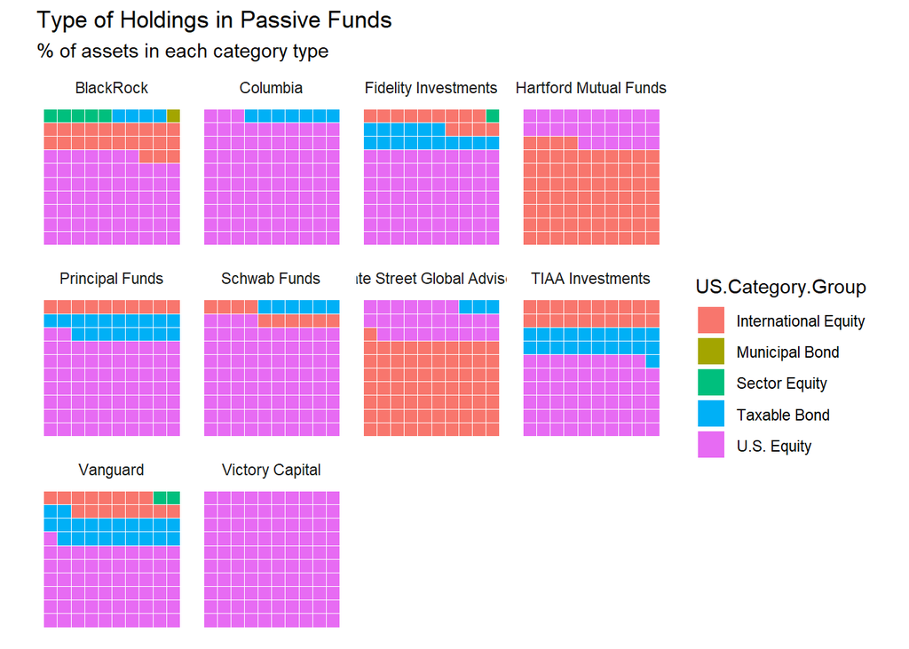

## Fees by Share Class of Passive Fund Holdings

Here I am looking at fund families’ fees for each share class types for passive funds. It’s the same as above except with share class type instead of U.S. category group.

```r
Passive_shareclass_type <- PassiveFunds %>%
  group_by(Firm.Name, Share.Class.Type) %>%
  summarise(
    Asst_Wted_Cat = sum(Asst_By_Fee_2019, na.rm = TRUE),
    Sum_Assets_Cat = sum(Net_Asst_2019_AVG, na.rm = TRUE),
    Fee_Wted_Cat = Asst_Wted_Cat / Sum_Assets_Cat,
    Cat_Count = n()
  ) %>%
  group_by(Firm.Name) %>%
  mutate(
    ShareClass_Count = sum(Cat_Count, na.rm = TRUE),
    Sum_Assts_Wted = sum(Asst_Wted_Cat, na.rm = TRUE),
    Sum_Assets = sum(Sum_Assets_Cat, na.rm = TRUE),
    Fee_Wted = Sum_Assts_Wted / Sum_Assets,
    pct_assets = (Sum_Assets_Cat / Sum_Assets) * 100
    ) %>%
  filter(ShareClass_Count >= 10 &
           Sum_Assets > 0
         )

#Passive_shareclass_type_Pct <- Passive_Cat %>%
#  select(Firm.Name, Share.Class.Type, pct_assets) %>%
#   #spread(Share.Class.Type, pct_assets) %>%
#  filter(
#    Firm.Name %in% c("Fidelity Investments",
#                      "Schwab Funds",
#                      "Vanguard",
#                      "TIAA Investments",
#                      "BlackRock",
#                      "State Street Global Advisors",
#                      "Principal Funds",
#                      "Columbia",
#                      "Victory Capital",
#                      "Hartford Mutual Funds")
#     ) %>%
#   group_by(Firm.Name) %>%
#   arrange(-pct_assets, .by_group = TRUE)
```

## Fee changes among passive share classes

Here I am looking at how many Passive share classes had fees that were cut and hiked or saw no change. I start by filtering out non-index funds and fees that are NA (blank) for 2019 and 2018. I also remove fees with a zero expense ratio for 2018 because we can’t calculate change with that base.

Next I created a category (FeeChange) that puts the percent changes (continous) in buckets (categorical). After that I just count the buckets.

Filter:

- Firms with at least 10 share classes
- Firms with at least $1 in assets

```r
Passive_Shareclass <- Adjusted_Data %>%
  filter(
    Annual.Report..Net.Expense..Ratio..Year2018 != 0 &
      !is.na(Annual.Report..Net.Expense..Ratio..Year2018) &
      !is.na(Annual.Report..Net.Expense..Ratio..Year2019) &
      Index..Fund == "Yes"
  ) %>%
  mutate(
    FeeChange =
      cut(
        Pct_Change_2018_2019,
        breaks = c(-Inf, -0.001, 0, Inf),
        labels = c("Cut", "No Change", "Hike"),
        include.lowest = TRUE,
        right = TRUE
      )
    )

Passive_Summary_Shareclass <- Passive_Shareclass %>%
  group_by(Firm.Name,
           FeeChange) %>%
  summarise(count = n(),
    Sum_Assets = sum(Net_Asst_2019_AVG, na.rm = TRUE),
    ) %>%
  group_by(Firm.Name) %>%
  mutate(
    total_assets = sum(Sum_Assets),
    assets_pct = Sum_Assets/total_assets * 100,
    total_count = sum(count),
    count_pct = count / total_count * 100
  ) %>%
  filter(
    total_count >= 10 &
      total_assets > 0
    )

write_csv(
  Passive_Summary_Shareclass,
  "~/Data/Fee_Data/Fee_Data/results/PASSIVE/shareclass_changes_passivefunds.csv"
  )
```

Here’s a look at some of the above data. Full results saved as **shareclass_changes_passivefunds.csv** in **Results** folder.

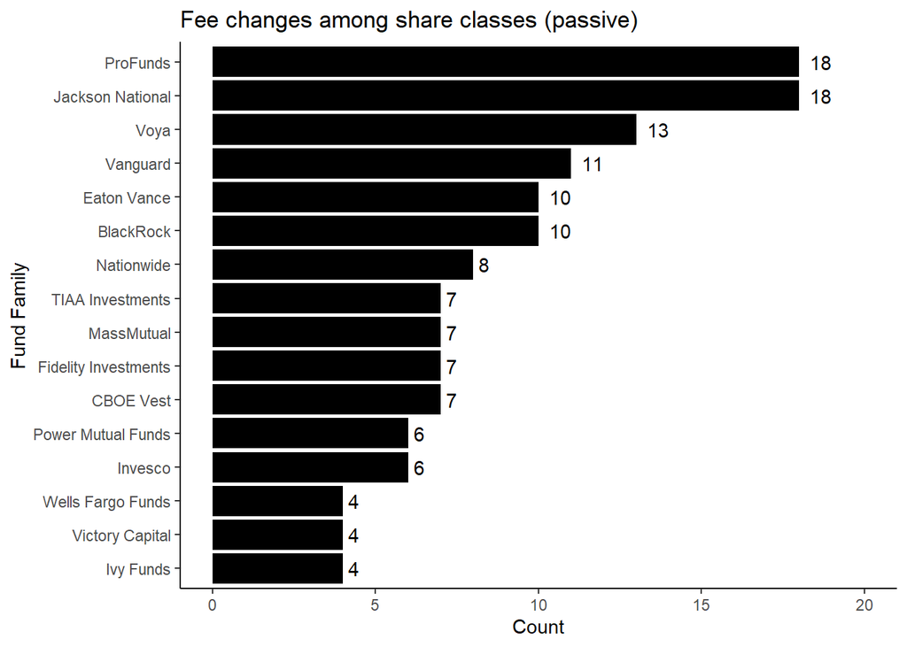

# General

## Fee changes among share classes (active & passive)

Here I am looking at how many share classes had fees that were cut and hiked or saw no change.

I start by filtering out fees that are NA (blank) for 2019 and 2018. I also remove fees with a zero expense ratio for 2018 because we can’t calculate change with that base.

Next I create a category (FeeChange) that puts the percent changes (continous) in buckets (categorical). After that I just count the buckets.

```r
Shareclass <- Adjusted_Data %>%
  filter(
    Annual.Report..Net.Expense..Ratio..Year2018 != 0 &
      !is.na(Annual.Report..Net.Expense..Ratio..Year2018) &
      !is.na(Annual.Report..Net.Expense..Ratio..Year2019)
  ) %>%
  mutate(
    FeeChange =
      cut(
        Pct_Change_2018_2019,
        breaks = c(-Inf,-0.001, 0, Inf),
        labels = c("Cut", "No Change", "Hike"),
        include.lowest = TRUE,
        right = TRUE)
    )

write_csv(Shareclass,
          "~/Data/Fee_Data/Fee_Data/results/shareclass_fee_changes.csv"
          )

Summary_Shareclass <- Shareclass %>%
  group_by(Firm.Name,
           FeeChange,) %>%
  summarise(count = n()
            ) %>%
  group_by(Firm.Name
  ) %>%
  mutate(
    total_count = sum(count)
  )
```

Here’s a look at some of the above data. Full results saved as **shareclass_fee_changes.csv** in **Results** folder.

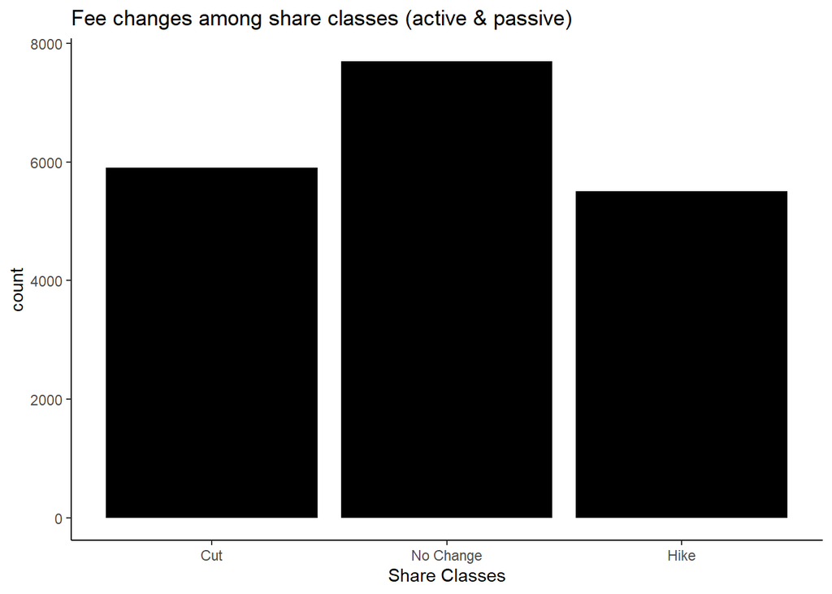

## % change of share class fees from 2018 to 2019

Here I at look how deep firms slashed their expense ratios from 2018 to 2019. First, I removed rows with an expense ratio of zero in 2018 because I can’t calculate changes with that base. I also filter out expense ratios listed as NA (blank) for 2018 and 2019.

Now I need to put the percent change in fees from 2018 to 2019 into buckets. I did that with the cut() function. Here’s a [link](https://rpubs.com/pierrelafortune/cutdocumentation) for personal reference.

```r
Category <- Adjusted_Data %>%
  select(1:20,
         90:97) %>%
  filter(
    Annual.Report..Net.Expense..Ratio..Year2018 != 0 &
      !is.na(Annual.Report..Net.Expense..Ratio..Year2018) &
      !is.na(Annual.Report..Net.Expense..Ratio..Year2019)
  ) %>%
  mutate(
    FeeChange =
      cut(
        Pct_Change_2018_2019,
        breaks = c(-Inf, -50, -25, -10, -1, -0.01, 0, Inf),
        labels = c("< -50", "-25 - -50", "-10 - -25", "-1 - 10", "0 - -1", "0", "> 0"),
        include.lowest = TRUE,
        right = TRUE
      )
  )

write_csv(Category,
          "~/Data/Fee_Data/Fee_Data/results/shareclass_cuts_total.csv")

Summary_Category <- Category %>%
  group_by(FeeChange) %>%
  summarise(count = n())

datatable(Summary_Category)
```

|  | FeeChange | count |
| --- | --- | --- |
| 1 | &lt; -50 | 70 |
| 2 | -25 - -50 | 147 |
| 3 | -10 - -25 | 610 |
| 4 | -1 - 10 | 4203 |
| 5 | 0 - -1 | 872 |
| 6 | 0 | 7703 |
| 7 | &gt; 0 | 5509 |

Here’s a look at the above data. Full results saved as **shareclass_cuts_total.csv** in **Results** folder.

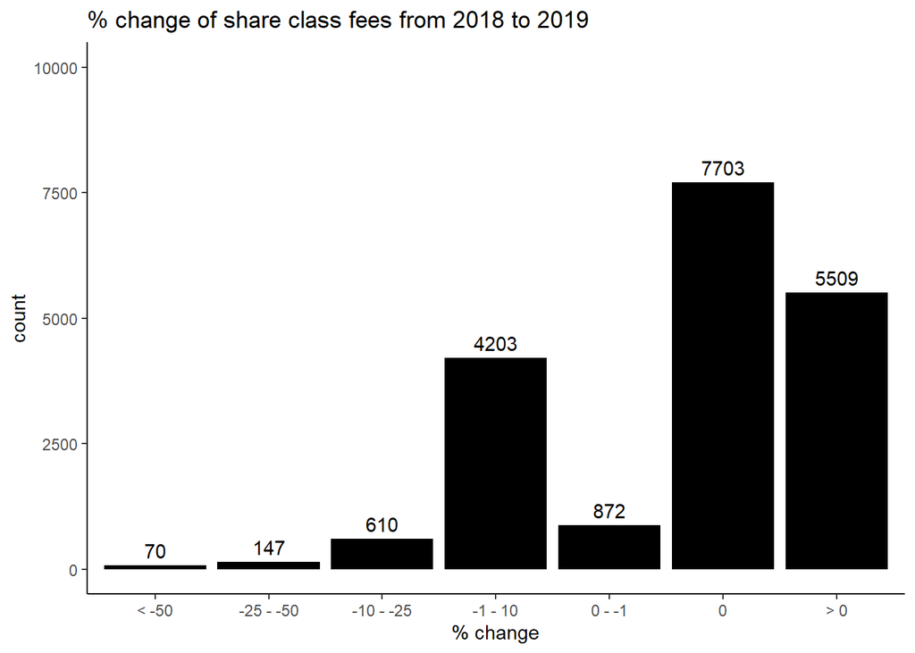